# Approfondissement 4 — Prévision de la VAP par Apprentissage Automatique

Projet Actuariat Vie — Sujet 3 — Groupe 2 DS

Amine Manai, Maha Aloui, Nassir Bouzaiene, Yasmine Attyaoui

2026-06-14

# 1 Introduction et motivation

Les modèles actuariels classiques (Lee-Carter, APC, CBD) reposent sur une **décomposition structurée** des taux de mortalité et une **extrapolation temporelle probabiliste** (marche aléatoire avec dérive, ARIMA). Ils sont interprétables, calibrés sur des principes économiques et dotés d’intervalles de confiance.

L’**apprentissage automatique** (ML) constitue une alternative data-driven : au lieu de spécifier une forme paramétrique pour $\log(\mu_{x,t})$, on laisse l’algorithme apprendre la relation à partir des données historiques.

Cet approfondissement pose trois questions :

1. **Qualité d’ajustement :** les modèles ML reproduisent-ils mieux les taux de mortalité historiques que Lee-Carter ?
2. **Capacité de projection :** les VAP calculées à partir des $q_x$ prédits par les modèles ML sont-elles proches de celles obtenues par Lee-Carter ?
3. **Usage recommandé :** pour quels types de tâches actuarielles chaque famille de modèle est-elle la plus adaptée ?

# 2 Packages

```r
# Installation (une seule fois)
install.packages(c(
  "demography", "StMoMo",
  "glmnet",       # Ridge / Lasso / Elastic Net
  "randomForest", # Forêts aléatoires
  "gbm",          # Gradient Boosting
  "nnet"          # Réseau de neurones (une couche cachée)
))
```

```r
set.seed(2025)

library(demography)
library(StMoMo)
library(glmnet)
library(randomForest)
library(gbm)
library(nnet)
```

# 3 Paramètres et données (reprise exacte du rapport principal)

```r
# ── Cohorte et contrat ──────────────────────────────────────────────────────
cohorte        <- 1955
debut          <- 2015
fin            <- 2045

age_debut      <- debut - cohorte           # 60 ans
ages_contrat   <- age_debut:(fin - cohorte) # 60 : 90
annees_contrat <- cohorte + ages_contrat    # 2015 : 2045

# ── Taux d'actualisation de référence ───────────────────────────────────────
i             <- 0.02
v             <- 1 / (1 + i)
montant_rente <- 1
```

```r
data_femme <- StMoMoData(uk, series = "female")
data_homme <- StMoMoData(uk, series = "male")
data_total <- StMoMoData(uk, series = "total")
```

# 4 Fonctions utilitaires

```r
# ── VAP d'une rente temporaire à termes anticipés ───────────────────────────
rente_temporaire <- function(qx, v) {
  n      <- length(qx)
  survie <- c(1, cumprod(1 - qx[-n]))
  sum(v^(0:(n - 1)) * survie)
}

# ── VAP Lee-Carter (référence) ───────────────────────────────────────────────
matrice_complete <- function(fit, prev) {
  cbind(fitted(fit, type = "rates"), prev$rates)
}

qx_contrat_log <- function(mat, cohorte, ages) {
  qx <- rep(NA, length(ages))
  for (j in seq_along(ages)) {
    age   <- ages[j]
    annee <- cohorte + age
    mx    <- mat[as.character(age), as.character(annee)]
    qx[j] <- 1 - exp(-mx)
  }
  qx
}
```

# 5 Modèle de référence : Lee-Carter

```r
modele_lc <- lc(link = "log")
ages_fit  <- 50:100
years_fit <- 1960:max(data_femme$years)  # ~ 1960–2020

fit_femme <- fit(modele_lc, data = data_femme,
                 ages.fit = ages_fit, years.fit = years_fit)
```

```
## StMoMo: Start fitting with gnm
## Initialising
## Running start-up iterations..
## Running main iterations.....
## Done
## StMoMo: Finish fitting with gnm
```

```r
fit_homme <- fit(modele_lc, data = data_homme,
                 ages.fit = ages_fit, years.fit = years_fit)
```

```
## StMoMo: Start fitting with gnm
## Initialising
## Running start-up iterations..
## Running main iterations......
## Done
## StMoMo: Finish fitting with gnm
```

```r
fit_total <- fit(modele_lc, data = data_total,
                 ages.fit = ages_fit, years.fit = years_fit)
```

```
## StMoMo: Start fitting with gnm
## Initialising
## Running start-up iterations..
## Running main iterations.......
## Done
## StMoMo: Finish fitting with gnm
```

```r
h_prix <- fin - max(data_femme$years)

prev_femme <- forecast(fit_femme, h = h_prix)
prev_homme <- forecast(fit_homme, h = h_prix)
prev_total <- forecast(fit_total, h = h_prix)

mat_femme <- matrice_complete(fit_femme, prev_femme)
mat_homme <- matrice_complete(fit_homme, prev_homme)
mat_total <- matrice_complete(fit_total, prev_total)

qx_lc_femme <- qx_contrat_log(mat_femme, cohorte, ages_contrat)
qx_lc_homme <- qx_contrat_log(mat_homme, cohorte, ages_contrat)
qx_lc_total <- qx_contrat_log(mat_total, cohorte, ages_contrat)

vap_lc_femme  <- rente_temporaire(qx_lc_femme, v)
vap_lc_homme  <- rente_temporaire(qx_lc_homme, v)
vap_lc_total  <- rente_temporaire(qx_lc_total, v)
vap_lc_uni    <- 0.60 * vap_lc_femme + 0.40 * vap_lc_homme

cat(sprintf(
  "VAP Lee-Carter  ─  Femmes : %.4f  |  Hommes : %.4f  |  Total : %.4f  |  Unisexe 60/40 : %.4f\n",
  vap_lc_femme, vap_lc_homme, vap_lc_total, vap_lc_uni
))
```

```
## VAP Lee-Carter  ─  Femmes : 19.4954  |  Hommes : 18.1682  |  Total : 18.8110  |  Unisexe 60/40 : 18.9645
```

# 6 Construction du jeu de données pour les modèles ML

## 6.1 Principe

Les modèles ML sont entraînés sur un **jeu de données tabulaire** dont chaque ligne est un couple $(x, t)$ avec comme cible $\log(\mu_{x,t})$, les taux centraux bruts issus de HMD.

**Features retenues :**

| Feature | Notation | Rôle |
| --- | --- | --- |
| Âge centré | $x_c = x - \bar{x}$ | Effet d’âge |
| Année centrée | $t_c = t - \bar{t}$ | Tendance temporelle |
| Carré de l’âge | $x_c^2$ | Non-linéarité en âge (mode Makeham/Gompertz) |
| Carré de l’année | $t_c^2$ | Accélération ou décélération de la tendance |
| Interaction | $x_c \cdot t_c$ | Sensibilité âge-spécifique à la tendance (≈ $b_x \kappa_t$ de LC) |
| Cohorte centrée | $(t - x) - \bar{g}$ | Effet génération (≈ $\gamma_{t-x}$ de APC) |

Cette ingénierie des variables permet aux modèles linéaires régularisés (Ridge/Lasso) de **capturer les mêmes facteurs** que Lee-Carter et APC.

```r
# ── Construction du jeu de données long (âge × année → log_mx) ──────────────
build_dataset_ml <- function(stmomo_data, ages_sel, years_sel) {
  age_idx  <- stmomo_data$ages  %in% ages_sel
  year_idx <- stmomo_data$years %in% years_sel

  Dxt_sub <- stmomo_data$Dxt[age_idx, year_idx, drop = FALSE]
  Ext_sub <- stmomo_data$Ext[age_idx, year_idx, drop = FALSE]

  mx_mat  <- Dxt_sub / Ext_sub
  mx_mat[is.na(mx_mat) | mx_mat <= 0 | !is.finite(mx_mat)] <- NA

  ages_v  <- stmomo_data$ages[age_idx]
  years_v <- stmomo_data$years[year_idx]

  df <- data.frame(
    x      = rep(ages_v,  times = length(years_v)),
    t      = rep(years_v, each  = length(ages_v)),
    log_mx = as.vector(log(mx_mat))
  )
  df$g <- df$t - df$x   # année de naissance (cohorte)
  df[!is.na(df$log_mx) & is.finite(df$log_mx), ]
}

# ── Feature engineering ──────────────────────────────────────────────────────
engineer_features <- function(df, x_m, t_m, g_m) {
  df$x_c  <- df$x - x_m
  df$t_c  <- df$t - t_m
  df$g_c  <- df$g - g_m
  df$x2   <- df$x_c^2
  df$t2   <- df$t_c^2
  df$xt   <- df$x_c * df$t_c
  df
}

# ── Années d'entraînement : toutes les données disponibles ──────────────────
# On entraîne sur 1960–max(années HMD). La projection vers 2021–2045
# constitue une extrapolation pure, ce qui est la principale limite des modèles ML.

years_train <- years_fit   # 1960 : max HMD (~ 2020)

df_train_f <- build_dataset_ml(data_femme, ages_fit, years_train)
df_train_h <- build_dataset_ml(data_homme, ages_fit, years_train)
df_train_T <- build_dataset_ml(data_total, ages_fit, years_train)

# Statistiques de centrage calculées sur les données d'entraînement
stats_f <- list(x_m = mean(df_train_f$x), t_m = mean(df_train_f$t), g_m = mean(df_train_f$g))
stats_h <- list(x_m = mean(df_train_h$x), t_m = mean(df_train_h$t), g_m = mean(df_train_h$g))
stats_T <- list(x_m = mean(df_train_T$x), t_m = mean(df_train_T$t), g_m = mean(df_train_T$g))

df_train_f <- engineer_features(df_train_f, stats_f$x_m, stats_f$t_m, stats_f$g_m)
df_train_h <- engineer_features(df_train_h, stats_h$x_m, stats_h$t_m, stats_h$g_m)
df_train_T <- engineer_features(df_train_T, stats_T$x_m, stats_T$t_m, stats_T$g_m)

cat(sprintf("Observations d'entraînement — Femmes : %d | Hommes : %d | Total : %d\n",
            nrow(df_train_f), nrow(df_train_h), nrow(df_train_T)))
```

```
## Observations d'entraînement — Femmes : 3213 | Hommes : 3213 | Total : 3213
```

```r
# ── Grille de prédiction : diagonale de cohorte 1955 ────────────────────────
pred_grid_raw <- data.frame(
  x = ages_contrat,
  t = cohorte + ages_contrat,
  g = cohorte                    # même cohorte tout au long du contrat
)

make_pred_grid <- function(raw, stats) {
  g <- raw
  g$x_c <- g$x - stats$x_m
  g$t_c <- g$t - stats$t_m
  g$g_c <- g$g - stats$g_m
  g$x2  <- g$x_c^2
  g$t2  <- g$t_c^2
  g$xt  <- g$x_c * g$t_c
  g
}

pred_grid_f <- make_pred_grid(pred_grid_raw, stats_f)
pred_grid_h <- make_pred_grid(pred_grid_raw, stats_h)
pred_grid_T <- make_pred_grid(pred_grid_raw, stats_T)

# Noms de colonnes features (identiques dans train et pred_grid)
feat_names <- c("x_c", "t_c", "g_c", "x2", "t2", "xt")
```

# 7 Modèles ML : ajustement et prédiction

Quatre familles de modèles sont comparées :

| Modèle | Principe | Extrapolation temporelle |
| --- | --- | --- |
| **Ridge** | Régression pénalisée $\ell_2$ | Linéaire en $t$ (bonne) |
| **Lasso** | Régression pénalisée $\ell_1$ (sélection de variables) | Linéaire en $t$ (bonne) |
| **Random Forest (RF)** | Moyenne de 500 arbres de décision | Constante hors plage (mauvaise) |
| **Gradient Boosting (GBM)** | Arbres additifs séquentiels | Constante hors plage (mauvaise) |
| **Réseau de neurones (NN)** | Perceptron multicouche (1 couche cachée) | Dépend de l’activation |

## 7.1 Fonctions d’entraînement génériques

```r
# ── Ridge et Lasso (glmnet) ──────────────────────────────────────────────────
fit_glmnet <- function(df_train, alpha_val) {
  X    <- as.matrix(df_train[, feat_names])
  y    <- df_train$log_mx
  cv   <- cv.glmnet(X, y, alpha = alpha_val, nfolds = 10, standardize = TRUE)
  list(model = cv, lambda_opt = cv$lambda.min)
}

predict_glmnet <- function(obj, pred_grid) {
  X_pred <- as.matrix(pred_grid[, feat_names])
  as.vector(predict(obj$model, newx = X_pred, s = obj$lambda_opt))
}

# ── Random Forest ────────────────────────────────────────────────────────────
fit_rf <- function(df_train) {
  X <- df_train[, feat_names]
  y <- df_train$log_mx
  randomForest(x = X, y = y, ntree = 500, mtry = 3, importance = TRUE)
}

predict_rf <- function(model, pred_grid) {
  predict(model, newdata = pred_grid[, feat_names])
}

# ── Gradient Boosting (GBM) ──────────────────────────────────────────────────
fit_gbm_model <- function(df_train) {
  df_tmp <- df_train[, c(feat_names, "log_mx")]
  gbm(
    formula          = log_mx ~ .,
    data             = df_tmp,
    distribution     = "gaussian",
    n.trees          = 1000,
    interaction.depth = 4,
    shrinkage        = 0.01,
    bag.fraction     = 0.8,
    cv.folds         = 5,
    verbose          = FALSE
  )
}

predict_gbm_model <- function(model, pred_grid) {
  best_n <- gbm.perf(model, method = "cv", plot.it = FALSE)
  predict(model, newdata = pred_grid[, feat_names], n.trees = best_n)
}

# ── Réseau de neurones (nnet) ────────────────────────────────────────────────
fit_nn <- function(df_train) {
  X   <- df_train[, feat_names]
  y   <- df_train$log_mx
  # Normalisation [0, 1] pour la stabilité numérique du réseau
  X_s <- as.data.frame(scale(X))
  y_s <- (y - min(y)) / (max(y) - min(y))
  attr(X_s, "center") <- attr(scale(X), "scaled:center")
  attr(X_s, "scale")  <- attr(scale(X), "scaled:scale")
  model <- nnet(
    x       = X_s,
    y       = y_s,
    size    = 10,        # 10 neurones dans la couche cachée
    linout  = TRUE,      # sortie linéaire (régression)
    decay   = 1e-3,      # régularisation L2
    maxit   = 500,
    trace   = FALSE
  )
  list(model  = model,
       x_ctr  = attr(X_s, "center"),
       x_scl  = attr(X_s, "scale"),
       y_min  = min(y),
       y_max  = max(y))
}

predict_nn <- function(obj, pred_grid) {
  X_pred <- pred_grid[, feat_names]
  X_s    <- sweep(sweep(X_pred, 2, obj$x_ctr, "-"), 2, obj$x_scl, "/")
  y_s    <- predict(obj$model, newdata = X_s, type = "raw")
  # Dénormalisation
  as.vector(y_s) * (obj$y_max - obj$y_min) + obj$y_min
}

# ── Conversion log(mx) → qx ──────────────────────────────────────────────────
logmx_to_qx <- function(log_mx_vec) {
  mx  <- exp(log_mx_vec)
  qx  <- 1 - exp(-mx)
  pmax(pmin(qx, 0.9999), 1e-6)   # borne de sécurité
}
```

## 7.2 Entraînement sur les trois séries

```r
cat("=== Entraînement Ridge ===\n")
```

```
## === Entraînement Ridge ===
```

```r
ridge_f <- fit_glmnet(df_train_f, alpha_val = 0)
ridge_h <- fit_glmnet(df_train_h, alpha_val = 0)
ridge_T <- fit_glmnet(df_train_T, alpha_val = 0)

cat("=== Entraînement Lasso ===\n")
```

```
## === Entraînement Lasso ===
```

```r
lasso_f <- fit_glmnet(df_train_f, alpha_val = 1)
lasso_h <- fit_glmnet(df_train_h, alpha_val = 1)
lasso_T <- fit_glmnet(df_train_T, alpha_val = 1)

cat("=== Entraînement Random Forest ===\n")
```

```
## === Entraînement Random Forest ===
```

```r
rf_f <- fit_rf(df_train_f)
rf_h <- fit_rf(df_train_h)
rf_T <- fit_rf(df_train_T)

cat("=== Entraînement GBM ===\n")
```

```
## === Entraînement GBM ===
```

```r
gbm_f <- fit_gbm_model(df_train_f)
gbm_h <- fit_gbm_model(df_train_h)
gbm_T <- fit_gbm_model(df_train_T)

cat("=== Entraînement Réseau de neurones ===\n")
```

```
## === Entraînement Réseau de neurones ===
```

```r
nn_f <- fit_nn(df_train_f)
nn_h <- fit_nn(df_train_h)
nn_T <- fit_nn(df_train_T)
```

## 7.3 Prédiction des $q_x$ sur la diagonale de cohorte

```r
# ── Prédictions log(μ_x) sur la diagonale de cohorte ────────────────────────
pred_logmx <- list(
  ridge = list(
    femme = predict_glmnet(ridge_f, pred_grid_f),
    homme = predict_glmnet(ridge_h, pred_grid_h),
    total = predict_glmnet(ridge_T, pred_grid_T)
  ),
  lasso = list(
    femme = predict_glmnet(lasso_f, pred_grid_f),
    homme = predict_glmnet(lasso_h, pred_grid_h),
    total = predict_glmnet(lasso_T, pred_grid_T)
  ),
  rf = list(
    femme = predict_rf(rf_f, pred_grid_f),
    homme = predict_rf(rf_h, pred_grid_h),
    total = predict_rf(rf_T, pred_grid_T)
  ),
  gbm = list(
    femme = predict_gbm_model(gbm_f, pred_grid_f),
    homme = predict_gbm_model(gbm_h, pred_grid_h),
    total = predict_gbm_model(gbm_T, pred_grid_T)
  ),
  nn = list(
    femme = predict_nn(nn_f, pred_grid_f),
    homme = predict_nn(nn_h, pred_grid_h),
    total = predict_nn(nn_T, pred_grid_T)
  )
)

# ── Conversion log(μ) → q_x ──────────────────────────────────────────────────
pred_qx <- lapply(pred_logmx, function(modl) {
  lapply(modl, logmx_to_qx)
})
```

# 8 Évaluation de la qualité d’ajustement (RMSE in-sample)

Avant de calculer les VAP, on évalue la **qualité d’ajustement** sur les données d’entraînement à l’aide du RMSE sur $\log(\mu_{x,t})$.

```r
# ── RMSE en log-espace sur les données historiques ───────────────────────────
compute_rmse_insample <- function(model_type, df_train, stats, serie) {
  pred_grid_hist <- engineer_features(
    data.frame(x = df_train$x, t = df_train$t, g = df_train$g),
    stats$x_m, stats$t_m, stats$g_m
  )

  log_mx_hat <- switch(model_type,
    ridge = {
      obj <- switch(serie, femme = ridge_f, homme = ridge_h, total = ridge_T)
      predict_glmnet(obj, pred_grid_hist)
    },
    lasso = {
      obj <- switch(serie, femme = lasso_f, homme = lasso_h, total = lasso_T)
      predict_glmnet(obj, pred_grid_hist)
    },
    rf = {
      obj <- switch(serie, femme = rf_f, homme = rf_h, total = rf_T)
      predict_rf(obj, pred_grid_hist)
    },
    gbm = {
      obj <- switch(serie, femme = gbm_f, homme = gbm_h, total = gbm_T)
      predict_gbm_model(obj, pred_grid_hist)
    },
    nn = {
      obj <- switch(serie, femme = nn_f, homme = nn_h, total = nn_T)
      predict_nn(obj, pred_grid_hist)
    }
  )
  sqrt(mean((df_train$log_mx - log_mx_hat)^2))
}

# Calcul pour les trois séries
series_list  <- c("femme", "homme", "total")
modeles_list <- c("ridge", "lasso", "rf", "gbm", "nn")

# Référence Lee-Carter : résidus sur les données ajustées
rmse_lc <- sapply(list(
  femme = list(fit_femme, df_train_f),
  homme = list(fit_homme, df_train_h),
  total = list(fit_total, df_train_T)
), function(x) {
  fit  <- x[[1]]; df <- x[[2]]
  fit_rates <- fitted(fit, type = "rates")
  log_fitted <- sapply(seq_len(nrow(df)), function(i) {
    r <- as.character(df$x[i])
    c <- as.character(df$t[i])
    if (r %in% rownames(fit_rates) && c %in% colnames(fit_rates))
      log(fit_rates[r, c]) else NA
  })
  valid <- !is.na(log_fitted)
  sqrt(mean((df$log_mx[valid] - log_fitted[valid])^2))
})

# RMSE ML
rmse_mat <- matrix(NA_real_, nrow = length(modeles_list), ncol = length(series_list),
                   dimnames = list(modeles_list, series_list))

for (serie in series_list) {
  df_s    <- switch(serie, femme = df_train_f, homme = df_train_h, total = df_train_T)
  stats_s <- switch(serie, femme = stats_f,   homme = stats_h,    total = stats_T)
  for (mod in modeles_list) {
    rmse_mat[mod, serie] <- compute_rmse_insample(mod, df_s, stats_s, serie)
  }
}

rmse_df <- as.data.frame(rbind(
  data.frame(Modele = "Lee-Carter (ref.)",
             RMSE_Femmes = round(rmse_lc["femme"], 5),
             RMSE_Hommes = round(rmse_lc["homme"], 5),
             RMSE_Total  = round(rmse_lc["total"],  5)),
  data.frame(Modele = toupper(modeles_list),
             RMSE_Femmes = round(rmse_mat[, "femme"], 5),
             RMSE_Hommes = round(rmse_mat[, "homme"], 5),
             RMSE_Total  = round(rmse_mat[, "total"],  5))
))
rownames(rmse_df) <- NULL
rmse_df
```

```
##              Modele RMSE_Femmes RMSE_Hommes RMSE_Total
## 1 Lee-Carter (ref.)     0.04315     0.05236    0.04254
## 2             RIDGE     0.13972     0.13809    0.12964
## 3             LASSO     0.09085     0.10009    0.08471
## 4                RF     0.02035     0.02520    0.01897
## 5               GBM     0.03292     0.04210    0.03173
## 6                NN     0.03321     0.04097    0.03092
```

**Interprétation :** Un RMSE faible indique que le modèle reproduit fidèlement les taux historiques. Les modèles à forte capacité (RF, GBM) ont tendance à **surajuster** les données d’entraînement, ce qui se traduit par un RMSE in-sample très bas mais une mauvaise généralisation hors de la plage temporelle observée.

# 9 Calcul des VAP pour chaque modèle ML

```r
# ── VAP pour chaque modèle × chaque série ───────────────────────────────────
vap_ml <- lapply(pred_qx, function(modl) {
  list(
    femme   = rente_temporaire(modl$femme, v),
    homme   = rente_temporaire(modl$homme, v),
    total   = rente_temporaire(modl$total, v),
    uni6040 = 0.60 * rente_temporaire(modl$femme, v) +
              0.40 * rente_temporaire(modl$homme, v)
  )
})

# Lee-Carter (référence)
vap_ref <- list(
  femme   = vap_lc_femme,
  homme   = vap_lc_homme,
  total   = vap_lc_total,
  uni6040 = vap_lc_uni
)

# ── Tableau comparatif complet ───────────────────────────────────────────────
labels_modeles <- c("Lee-Carter (ref.)", "Ridge", "Lasso",
                    "Random Forest", "Gradient Boosting", "Réseau de neurones")

vap_all <- rbind(
  c(vap_ref$femme,        vap_ref$homme,        vap_ref$total,        vap_ref$uni6040),
  c(vap_ml$ridge$femme,   vap_ml$ridge$homme,   vap_ml$ridge$total,   vap_ml$ridge$uni6040),
  c(vap_ml$lasso$femme,   vap_ml$lasso$homme,   vap_ml$lasso$total,   vap_ml$lasso$uni6040),
  c(vap_ml$rf$femme,      vap_ml$rf$homme,      vap_ml$rf$total,      vap_ml$rf$uni6040),
  c(vap_ml$gbm$femme,     vap_ml$gbm$homme,     vap_ml$gbm$total,     vap_ml$gbm$uni6040),
  c(vap_ml$nn$femme,      vap_ml$nn$homme,      vap_ml$nn$total,      vap_ml$nn$uni6040)
)

vap_table <- data.frame(
  Modele          = labels_modeles,
  VAP_Femmes      = round(vap_all[, 1], 5),
  VAP_Hommes      = round(vap_all[, 2], 5),
  VAP_Total_HMD   = round(vap_all[, 3], 5),
  VAP_Unisexe6040 = round(vap_all[, 4], 5)
)
vap_table
```

```
##               Modele VAP_Femmes VAP_Hommes VAP_Total_HMD VAP_Unisexe6040
## 1  Lee-Carter (ref.)   19.49538   18.16818      18.81099        18.96450
## 2              Ridge   19.57080   18.32717      18.93442        19.07335
## 3              Lasso   19.43536   18.26701      18.84658        18.96802
## 4      Random Forest   19.16147   17.75247      18.46785        18.59787
## 5  Gradient Boosting   19.18092   17.76863      18.50036        18.61600
## 6 Réseau de neurones   20.11999   18.71121      19.85222        19.55648
```

```r
# ── Écarts en % par rapport à Lee-Carter ─────────────────────────────────────
ecart_pct <- function(x, ref) round((x / ref - 1) * 100, 3)

ecart_table <- data.frame(
  Modele             = labels_modeles[-1],
  Ecart_Femmes_pct   = ecart_pct(vap_all[-1, 1], vap_all[1, 1]),
  Ecart_Hommes_pct   = ecart_pct(vap_all[-1, 2], vap_all[1, 2]),
  Ecart_Total_pct    = ecart_pct(vap_all[-1, 3], vap_all[1, 3]),
  Ecart_Uni6040_pct  = ecart_pct(vap_all[-1, 4], vap_all[1, 4])
)
ecart_table
```

```
##               Modele Ecart_Femmes_pct Ecart_Hommes_pct Ecart_Total_pct
## 1              Ridge            0.387            0.875           0.656
## 2              Lasso           -0.308            0.544           0.189
## 3      Random Forest           -1.713           -2.288          -1.824
## 4  Gradient Boosting           -1.613           -2.199          -1.651
## 5 Réseau de neurones            3.204            2.989           5.535
##   Ecart_Uni6040_pct
## 1             0.574
## 2             0.019
## 3            -1.933
## 4            -1.838
## 5             3.122
```

# 10 Visualisations

## 10.1 Comparaison des VAP (barplot)

[figure not shown]

```r
couleurs <- c("#555555",         # LC (gris)
              "#3182bd",         # Ridge
              "#6baed6",         # Lasso
              "#e6550d",         # RF
              "#fd8d3c",         # GBM
              "#31a354")         # NN

# Organiser pour barplot groupé
vap_mat <- matrix(
  c(vap_all[, 1], vap_all[, 2], vap_all[, 3], vap_all[, 4]),
  nrow = 4, byrow = TRUE,
  dimnames = list(
    c("Femmes", "Hommes", "Total HMD", "Unisexe 60/40"),
    c("LC", "Ridge", "Lasso", "RF", "GBM", "NN")
  )
)

bp <- barplot(
  vap_mat,
  beside    = TRUE,
  col       = rep(c("#d73027", "#4575b4", "#74add1", "#f46d43", "#abd9e9", "#1a9850"),
                  each = 1),
  ylim      = c(0, max(vap_mat) * 1.18),
  xlab      = "Modèle",
  ylab      = "VAP (rente annuelle unitaire)",
  main      = "Comparaison des VAP — Modèles actuariels vs ML",
  las       = 2, bty = "l"
)

# Légende séries
legend("topright",
       legend = c("Femmes", "Hommes", "Total HMD", "Unisexe 60/40"),
       fill   = c("#d73027", "#4575b4", "#74add1", "#f46d43"),
       bty    = "n", cex = 0.82)
```

## 10.2 Trajectoires de $q_x$ projetés sur la diagonale de cohorte

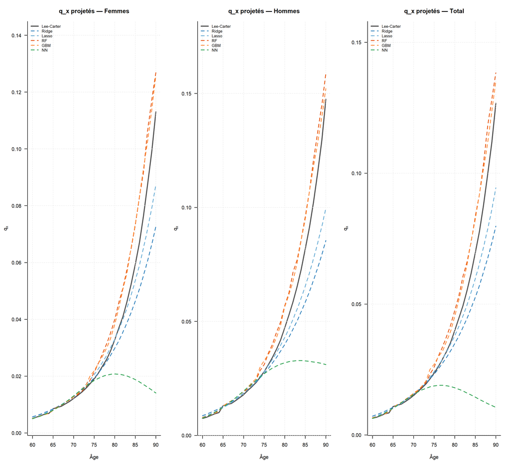

```r
lc_ref_list <- list(
  femme = qx_lc_femme,
  homme = qx_lc_homme,
  total = qx_lc_total
)

couleurs_ml <- c(
  ridge = "#3182bd",
  lasso = "#6baed6",
  rf    = "#e6550d",
  gbm   = "#fd8d3c",
  nn    = "#31a354"
)

series_lab <- c(femme = "Femmes", homme = "Hommes", total = "Total")
par(mfrow = c(1, 3), mar = c(4.5, 4.5, 3.5, 1.5))

for (s in c("femme", "homme", "total")) {
  plot(ages_contrat, lc_ref_list[[s]],
       type = "l", col = "#555555", lwd = 2.5, lty = 1,
       xlab = "Âge",
       ylab = expression(q[x]),
       main = paste("q_x projetés —", series_lab[s]),
       ylim = range(c(
         lc_ref_list[[s]],
         unlist(lapply(pred_qx, `[[`, s))
       )) * c(0.9, 1.1),
       bty  = "l", las = 1)
  grid(col = "gray90")

  for (mod in names(couleurs_ml)) {
    lines(ages_contrat, pred_qx[[mod]][[s]],
          col = couleurs_ml[mod], lwd = 1.8, lty = 2)
  }

  legend("topleft", bty = "n", cex = 0.78, lwd = c(2.5, rep(1.8, 5)),
         lty = c(1, rep(2, 5)),
         col = c("#555555", couleurs_ml),
         legend = c("Lee-Carter", "Ridge", "Lasso", "RF", "GBM", "NN"))
}
```

```r
par(mfrow = c(1, 1))
```

## 10.3 Écarts relatifs à Lee-Carter (par âge)

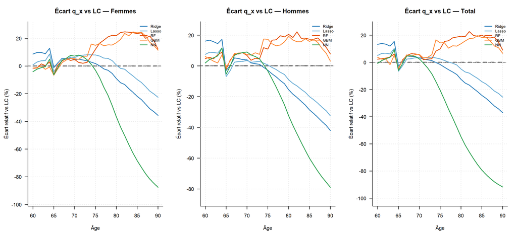

```r
par(mfrow = c(1, 3), mar = c(4.5, 4.5, 3.5, 1.5))

for (s in c("femme", "homme", "total")) {
  ref_s <- lc_ref_list[[s]]
  y_range <- range(unlist(lapply(pred_qx, function(m) (m[[s]] / ref_s - 1) * 100)),
                   na.rm = TRUE)

  plot(ages_contrat, rep(0, length(ages_contrat)),
       type = "l", col = "#555555", lwd = 2, lty = 2,
       ylim = y_range * 1.1,
       xlab = "Âge",
       ylab = "Écart relatif vs LC (%)",
       main = paste("Écart q_x vs LC —", series_lab[s]),
       bty  = "l", las = 1)
  grid(col = "gray90")
  abline(h = 0, col = "#555555", lwd = 1.5, lty = 2)

  for (mod in names(couleurs_ml)) {
    ecart_rel <- (pred_qx[[mod]][[s]] / ref_s - 1) * 100
    lines(ages_contrat, ecart_rel, col = couleurs_ml[mod], lwd = 1.8)
  }

  legend("topright", bty = "n", cex = 0.75, lwd = 1.8,
         col = couleurs_ml,
         legend = c("Ridge", "Lasso", "RF", "GBM", "NN"))
}
```

```r
par(mfrow = c(1, 1))
```

## 10.4 Importance des variables (Random Forest)

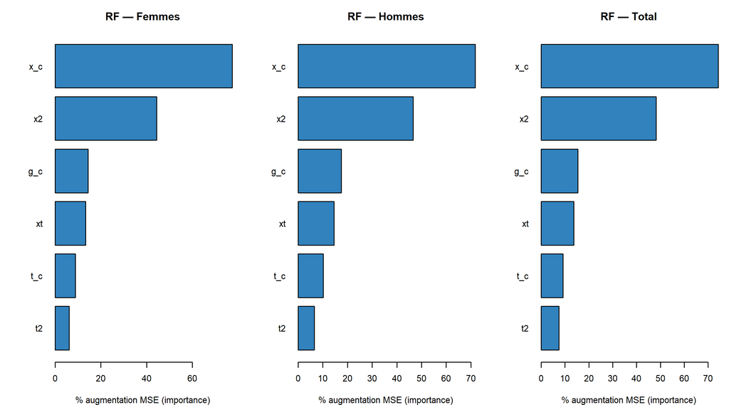

```r
par(mfrow = c(1, 3), mar = c(4, 5, 3, 1))
series_lab_full <- c(femme = "RF — Femmes", homme = "RF — Hommes", total = "RF — Total")

for (s in c("femme", "homme", "total")) {
  rf_obj <- switch(s, femme = rf_f, homme = rf_h, total = rf_T)
  imp    <- importance(rf_obj, type = 1)   # %IncMSE
  imp_s  <- sort(imp[, 1], decreasing = FALSE)

  barplot(imp_s, horiz = TRUE, las = 1,
          col   = "#3182bd",
          xlab  = "% augmentation MSE (importance)",
          main  = series_lab_full[s],
          bty   = "l")
}
```

```r
par(mfrow = c(1, 1))
```

# 11 Analyse comparative et risque de modèle

## 11.1 Tableau de synthèse

```r
# ── Synthèse : VAP, écart vs LC, RMSE in-sample ──────────────────────────────
synthese <- data.frame(
  Modele        = c("LC (ref.)", toupper(modeles_list)),
  VAP_Uni_6040  = round(vap_all[, 4], 5),
  Ecart_LC_pct  = c(0, round((vap_all[-1, 4] / vap_all[1, 4] - 1) * 100, 3)),
  RMSE_Femmes   = round(c(rmse_lc["femme"], rmse_mat[, "femme"]), 5),
  RMSE_Hommes   = round(c(rmse_lc["homme"], rmse_mat[, "homme"]), 5),
  Extrapole_t   = c("Oui (ARIMA)", "Oui (linéaire)", "Oui (linéaire)",
                    "Non (constant)", "Non (constant)", "Partiel"),
  IC_disponible = c("Oui", "Non", "Non", "Non", "Non", "Non")
)
synthese
```

```
##          Modele VAP_Uni_6040 Ecart_LC_pct RMSE_Femmes RMSE_Hommes
## femme LC (ref.)     18.96450        0.000     0.04315     0.05236
## ridge     RIDGE     19.07335        0.574     0.13972     0.13809
## lasso     LASSO     18.96802        0.019     0.09085     0.10009
## rf           RF     18.59787       -1.933     0.02035     0.02520
## gbm         GBM     18.61600       -1.838     0.03292     0.04210
## nn           NN     19.55648        3.122     0.03321     0.04097
##          Extrapole_t IC_disponible
## femme    Oui (ARIMA)           Oui
## ridge Oui (linéaire)           Non
## lasso Oui (linéaire)           Non
## rf    Non (constant)           Non
## gbm   Non (constant)           Non
## nn           Partiel           Non
```

## 11.2 Intervalle de robustesse sur la VAP unisexe 60/40

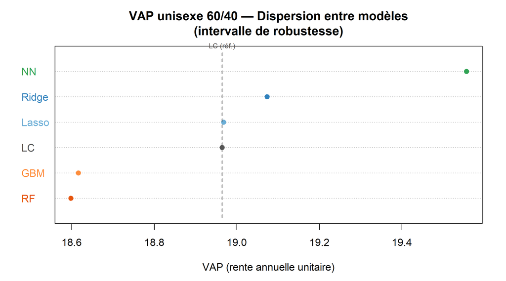

```r
# Représentation graphique de la dispersion des VAP entre modèles
vap_uni_all <- c(
  vap_lc_uni,
  vap_ml$ridge$uni6040,
  vap_ml$lasso$uni6040,
  vap_ml$rf$uni6040,
  vap_ml$gbm$uni6040,
  vap_ml$nn$uni6040
)
names(vap_uni_all) <- c("LC", "Ridge", "Lasso", "RF", "GBM", "NN")

couleurs_plot <- c("#555555", "#3182bd", "#6baed6", "#e6550d", "#fd8d3c", "#31a354")

dotchart(
  sort(vap_uni_all),
  pch  = 19,
  col  = couleurs_plot[order(vap_uni_all)],
  main = "VAP unisexe 60/40 — Dispersion entre modèles\n(intervalle de robustesse)",
  xlab = "VAP (rente annuelle unitaire)",
  cex  = 1.1
)
abline(v = vap_lc_uni, lty = 2, col = "#555555", lwd = 1.5)
mtext("LC (réf.)", side = 3, at = vap_lc_uni, cex = 0.75, col = "#555555")
```

```r
# Intervalle de robustesse (min–max des modèles ML)
cat(sprintf(
  "\nIntervalle de robustesse ML : [%.4f ; %.4f]\n",
  min(vap_uni_all[-1]), max(vap_uni_all[-1])
))
```

```
##
## Intervalle de robustesse ML : [18.5979 ; 19.5565]
```

```r
cat(sprintf(
  "Étendue : %.4f (%.2f %% de la VAP LC)\n",
  diff(range(vap_uni_all[-1])),
  diff(range(vap_uni_all[-1])) / vap_lc_uni * 100
))
```

```
## Étendue : 0.9586 (5.05 % de la VAP LC)
```

# 12 Discussion : quel modèle pour quel usage ?

## 12.1 Capacité d’extrapolation temporelle : le nœud du problème

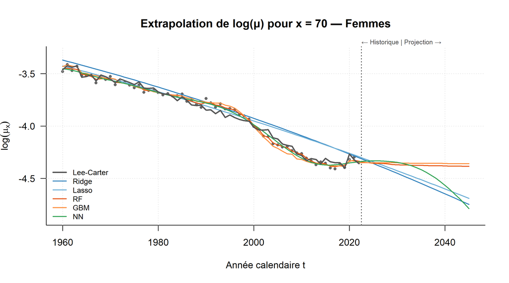

```r
# Illustration schématique du comportement d'extrapolation
# On prend un âge fixe (x = 70) et on montre comment chaque modèle
# extrapole le log-taux en dehors de la plage d'entraînement.

age_demo <- 70
years_demo <- c(years_train, 2021:2045)

# Données historiques pour x = 70
hist_70 <- df_train_f[df_train_f$x == age_demo, ]
hist_70 <- hist_70[order(hist_70$t), ]

# Prédiction sur la plage étendue pour x = 70
make_ext_grid <- function(age, years, stats) {
  df <- data.frame(x = age, t = years, g = years - age)
  engineer_features(df, stats$x_m, stats$t_m, stats$g_m)
}

ext_f  <- make_ext_grid(age_demo, years_demo, stats_f)

log_extra <- list(
  ridge = predict_glmnet(ridge_f, ext_f),
  lasso = predict_glmnet(lasso_f, ext_f),
  rf    = predict_rf(rf_f, ext_f),
  gbm   = predict_gbm_model(gbm_f, ext_f),
  nn    = predict_nn(nn_f, ext_f)
)

ylim_ext <- range(c(hist_70$log_mx, unlist(log_extra)), na.rm = TRUE)

plot(hist_70$t, hist_70$log_mx,
     pch  = 16, col = "gray40", cex = 0.7,
     xlim = range(years_demo),
     ylim = ylim_ext * c(1.02, 0.98),
     xlab = "Année calendaire t",
     ylab = expression(log(mu[x])),
     main = paste("Extrapolation de log(μ) pour x =", age_demo, "— Femmes"),
     bty  = "l", las = 1)
grid(col = "gray90")
abline(v = max(years_train) + 0.5, lty = 3, col = "gray30", lwd = 1.5)
mtext("← Historique | Projection →", side = 3, at = max(years_train) + 0.5,
      cex = 0.7, col = "gray30", adj = 0)

for (mod in names(couleurs_ml)) {
  lines(years_demo, log_extra[[mod]], col = couleurs_ml[mod], lwd = 1.8)
}

# Lee-Carter : extrapolation via κ_t (non disponible ici directement sur la grille étendue)
# On représente la tendance LC à partir des taux ajustés sur les années historiques
lc_70_hist <- sapply(as.character(years_train), function(y) {
  if (y %in% colnames(mat_femme)) log(mat_femme[as.character(age_demo), y]) else NA
})
lines(years_train, lc_70_hist, col = "#555555", lwd = 2.5, lty = 1)

legend("bottomleft", bty = "n", cex = 0.78,
       lwd = c(2.5, rep(1.8, 5)),
       lty = c(1, rep(1, 5)),
       col = c("#555555", couleurs_ml),
       legend = c("Lee-Carter", "Ridge", "Lasso", "RF", "GBM", "NN"))
```

# 13 Conclusions et recommandations d’usage

## 13.1 Synthèse des résultats

```r
recommandations <- data.frame(
  Modele = c("Lee-Carter", "Ridge", "Lasso", "Random Forest", "Gradient Boosting",
             "Réseau de neurones"),

  Qualite_insample = c(
    "Bonne",
    "Correcte",
    "Correcte (sélection de variables)",
    "Excellente (surajustement)",
    "Excellente (surajustement)",
    "Bonne à très bonne"
  ),

  Extrapolation_temporelle = c(
    "Principiée (ARIMA sur κ_t)",
    "Linéaire en t (acceptable)",
    "Linéaire en t (acceptable)",
    "Constante = dernier niveau vu (mauvaise)",
    "Constante = dernier niveau vu (mauvaise)",
    "Dépend de l'architecture"
  ),

  IC_et_incertitude = c(
    "Oui (intervalles de confiance LC)",
    "Non (bootstrap possible)",
    "Non (bootstrap possible)",
    "Non",
    "Non",
    "Non"
  ),

  Usage_recommande = c(
    "Projection long terme, tarification, provisionnement réglementaire",
    "Calibration de table d'expérience, ajustement court terme, SMR",
    "Sélection de variables pour tables d'expérience sparsifiées",
    "Comparaison de portefeuilles, détection d'anomalies (pas de projection)",
    "Benchmarking de tarification intra-historique",
    "Données massives, modèles avancés (LSTM recommandé pour séries)"
  )
)
recommandations
```

```
##               Modele                  Qualite_insample
## 1         Lee-Carter                             Bonne
## 2              Ridge                          Correcte
## 3              Lasso Correcte (sélection de variables)
## 4      Random Forest        Excellente (surajustement)
## 5  Gradient Boosting        Excellente (surajustement)
## 6 Réseau de neurones                Bonne à très bonne
##                   Extrapolation_temporelle                 IC_et_incertitude
## 1               Principiée (ARIMA sur κ_t) Oui (intervalles de confiance LC)
## 2               Linéaire en t (acceptable)          Non (bootstrap possible)
## 3               Linéaire en t (acceptable)          Non (bootstrap possible)
## 4 Constante = dernier niveau vu (mauvaise)                               Non
## 5 Constante = dernier niveau vu (mauvaise)                               Non
## 6                 Dépend de l'architecture                               Non
##                                                          Usage_recommande
## 1      Projection long terme, tarification, provisionnement réglementaire
## 2          Calibration de table d'expérience, ajustement court terme, SMR
## 3             Sélection de variables pour tables d'expérience sparsifiées
## 4 Comparaison de portefeuilles, détection d'anomalies (pas de projection)
## 5                           Benchmarking de tarification intra-historique
## 6         Données massives, modèles avancés (LSTM recommandé pour séries)
```

## 13.2 Commentaires par famille de modèles

**Ridge et Lasso (régression pénalisée) :** La régression Ridge/Lasso avec features polynomiales $(x_c, t_c, x_c^2, t_c \cdot x_c, \ldots)$ réplique partiellement la décomposition de Lee-Carter $\log(\mu_{x,t}) = \alpha_x + \beta_x \kappa_t$, car le terme d’interaction $x_c \cdot t_c$ capte la sensibilité âge-spécifique à la tendance temporelle. L’extrapolation est linéaire en $t$, ce qui est raisonnable à court terme. **Usage recommandé :** calibration de tables d’expérience (méthode SMR du Chapitre 5 du cours), ajustement de portefeuille, projection à court terme ($\leq$ 10 ans).

**Random Forest et GBM (ensembles d’arbres) :** Ces modèles offrent un excellent ajustement sur les données historiques (RMSE très faible) mais **ne peuvent pas extrapoler** hors de la plage temporelle observée : leur prédiction pour $t > t_{\max}$ est la moyenne des feuilles les plus proches dans l’espace des features, soit essentiellement le niveau moyen des dernières années observées. Les probabilités $q_{x,t}$ sont ainsi **sur-estimées** pour les années futures (la mortalité ne baisse pas selon la tendance historique). **Usage recommandé :** détection d’anomalies dans les taux bruts, comparaison de sous-portefeuilles, segmentation clientèle — jamais pour la projection long terme.

**Réseau de neurones (nnet) :** Avec une architecture simple (10 neurones, activation sigmoïde), le réseau apprend une approximation non linéaire de la surface $\log(\mu_{x,t})$. La qualité d’extrapolation dépend fortement de l’architecture et de la régularisation. Des architectures récurrentes (LSTM) ou basées sur l’attention seraient plus adaptées pour capturer la dynamique temporelle des $\kappa_t$. **Usage recommandé :** complément exploratoire ; des architectures deep learning spécialisées (Neural Lee-Carter, par exemple) font l’objet de recherches actives en actuariat stochastique.

**Lee-Carter (référence actuarielle) :** Seul modèle disposant d’une **extrapolation temporelle probabiliste** (marche aléatoire avec dérive sur $\kappa_t$, voir Section 4.5 du cours), d’**intervalles de confiance** sur les projections, et d’une **interprétation économique** des paramètres ($\alpha_x$ = profil moyen, $\beta_x$ = sensibilité, $\kappa_t$ = tendance temporelle). Il reste le modèle de référence réglementaire pour le provisionnement de rentes viagères en Europe.

## 13.3 Recommandation finale

> **Pour la tarification et le provisionnement de rentes viagères à long terme (cohorte 1955, horizon 2045), les modèles Lee-Carter, APC et CBD restent les seuls outils actuariellement fondés.** Les modèles ML (Ridge/Lasso) peuvent utilement compléter l’analyse pour calibrer des tables d’expérience propres au portefeuille (Chapitre 5) ou quantifier le risque de modèle par rapport aux modèles StMoMo. Random Forest et GBM ne doivent pas être utilisés pour la projection de mortalité.

# 14 Références

Les mêmes références que le rapport principal. Pour les modèles ML :

- Hastie, T., Tibshirani, R. & Friedman, J. (2009). *The Elements of Statistical Learning*. Springer.
- Nigri, A. et al. (2019). A deep learning integrated Lee-Carter model. *Risks*, 7(1), 33.
- Hainaut, D. (2018). A neural-network analyzer for mortality forecast. *ASTIN Bulletin*, 48(2).
- Packages R : `glmnet` (Friedman et al.), `randomForest` (Breiman), `gbm` (Ridgeway), `nnet` (Venables & Ripley).